# Incarceration Trends of Black People In Jail Population Data Visualization Analysis

Vincent Li

2022-11-23

## Abstract

This report analyze the incarceration data of the United States and provides data visualizations to find the patterns of inequality. It will summarize some interesting key variables that potentially reveal the inequality incarceration trend in some area of the United States. The visualizations show the trend of changes of the incarcerations status of certain area in certain year of the U.S.

## Introduction

The dataset is provided by the project of *Vera* that includes data collections from the Census of Jails (**COJ**) and the Annual Survey of Jails (**ASJ**) from 1970 to 2018. [incarceration trends](https://github.com/vera-institute/incarceration-trends). Through summarizing and visualizing the dataset, I want to find hidden patterns of potential inequality oppression in the prison system on black people.

The direct stakeholder of the project can be data scientists who are seeking to make analysis base on the helpful data resources of incarceration data. The indirect stakeholder can be prisoners in each region since the information of them are being recorded as datasets and published on websites.

The central value of this project is to provide statistical insights and to retrain inequality among communities. Minoritized and privileged hazard “power” issues might arise.

## Data Summary

##### Black Lives Matter movement begins in 2013. During this year, is there any inequality pattern on black people in the prison system that can possibly lead to the promotion of BLM movement?

##### The four variables summarized below might cover related values about jail population that is interesting to interpret.

```r
highest_proportion_black_2013
```

```
## # A tibble: 1 × 4
##   county_name   Avg_black Avg_jail proportion
##   <chr>             <dbl>    <dbl>      <dbl>
## 1 Mobile County      893.       96       9.31
```

- This value shows the proportion of black people in jail population in Mobile County, Alabama, in 2013. The reason that I choose 2013 as the interpreting year is because the Black Lives Matter movements started in 2013, which can possibly has more noticeable patterns. We can see that the proportion is unconventionally high and reach a number above 9.00. Therefore, we can interpret that there is inormal situation there.

```r
highest_proportion_black_2018
```

```
## # A tibble: 1 × 4
##   county_name    Avg_black Avg_jail proportion
##   <chr>              <dbl>    <dbl>      <dbl>
## 1 Caswell County        24        3          8
```

- This value shows the proportion of black people in jail population in Caswell County, North Carolina, in 2018. we can see that the county changes this time in 2018, but it is still unconventionally high.

```r
highest_change_proportion_black
```

```
## # A tibble: 1 × 2
##   county_name   change_in_proportion
##   <chr>                        <dbl>
## 1 Mobile County                -3.66
```

- This value interpret and find the county that has the highest change in proportion of black people in jail population from 2013 to 2018, and the result came up to be Mobile County, Alabama.

```r
proportion_black_jail_pop
```

```
## # A tibble: 1,876 × 4
##    county_name         Avg_black Avg_total proportion
##    <chr>                   <dbl>     <dbl>      <dbl>
##  1 Billings County          0.07         0    Inf
##  2 Loving County            0.05         0    Inf
##  3 Petroleum County         0.04         0    Inf
##  4 Gentry County           23.3         23      1.01
##  5 Wibaux County            1            1      1
##  6 Carlisle County         39.0         44      0.887
##  7 Throckmorton County      7.29         9      0.81
##  8 Daggett County           4            6      0.667
##  9 Toole County            20           35      0.571
## 10 Piatt County            33           70      0.471
## # … with 1,866 more rows
```

- This dataframe provides the order of county that has the proportion of average black people in jail versus average total black people in the county in 2013 from high to low.

## Growth of the U.S. Prison Population

##### What does this graph show about the trend of jail population in the U.S?

##### This chart shows the the change of the U.S. Prison Population from 1970 to 2018. We can see that starting late 1970s, the trend of total jail population continually increases each year until late 2000s, and remain relatively similar jail population in 2010s.

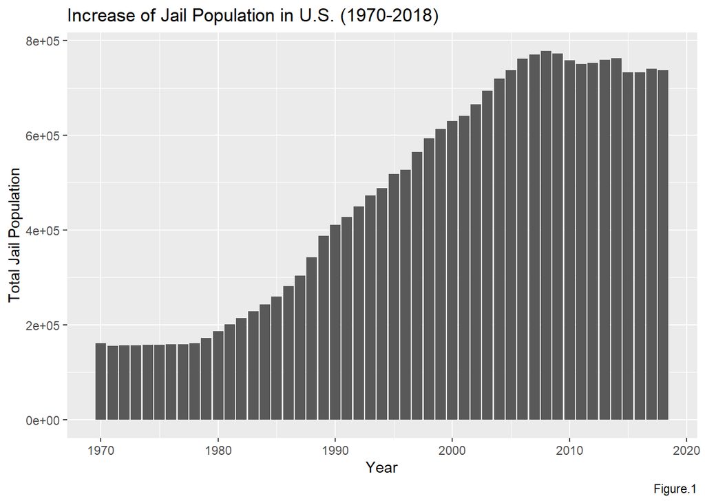

```r
plot_jail_pop_for_us()
```

## Growth of the Prison Population by State

##### What does this graph show about the difference of jail population between theses states?

##### This chart shows the change in jail population in five different states from 1970 to 2018. We can see that California has the highest jail population all time and has the greatest rate of increase trend from late 1970s to 2010s.

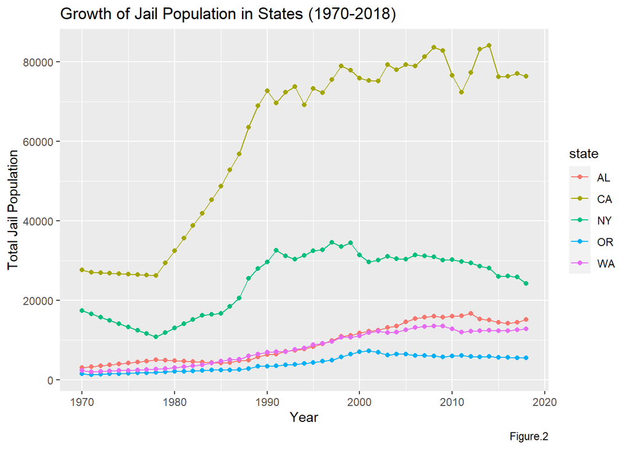

```r
check_states <- c("WA", "CA", "NY", "OR", "AL")

plot_jail_pop_by_states(check_states)
```

## Change in Black People Jail Proportion in Mobile County (1970-2018)

##### How does this graph indicate a inequality pattern?

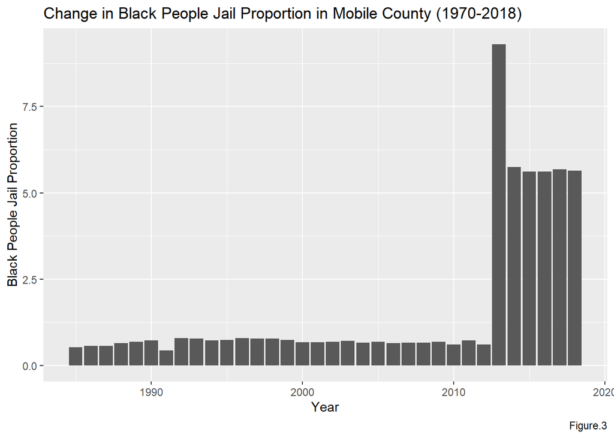

```r
plot_jail_prop_year_Mobile()
```

## Proportion of Black People in Jail Population Each State 2013

##### What is the overall situation happening in each states of black people in jail population?

##### This map shows the level of proportion of black people in jail population in each states of the U.S. Redder area indicates a higher level of proportion. The map reveals that states in mid-south or east tends to have higher level of proportion comparing to the west. This visualization might indicate a incarceration trend of inequality among some states.

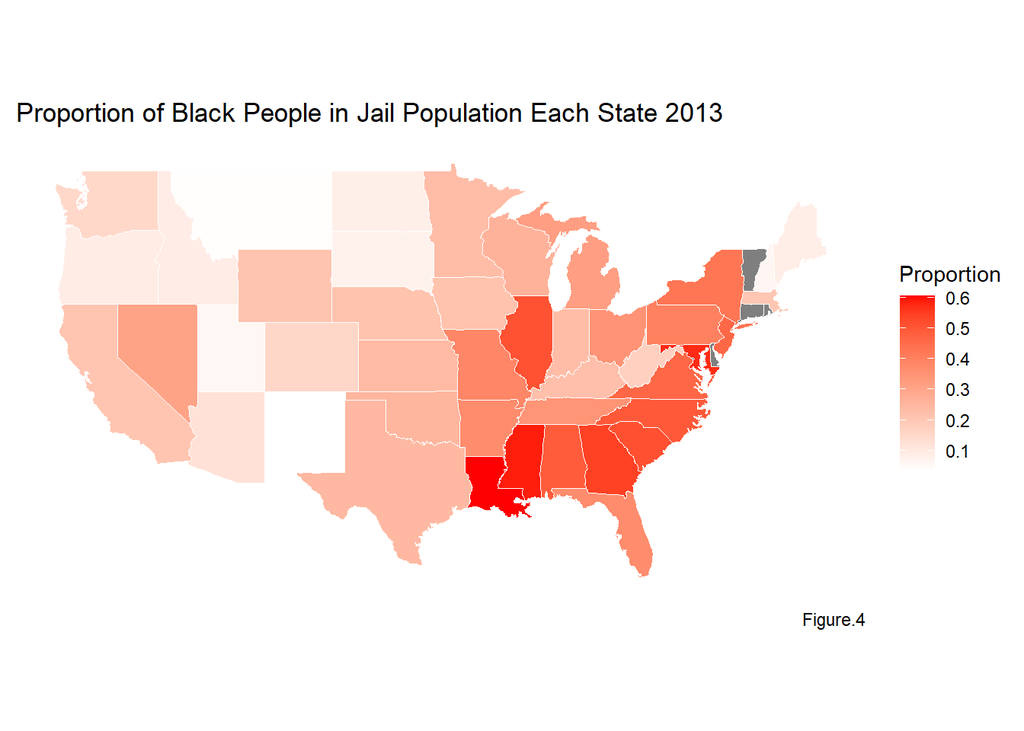

```r
map_black_jail_prop_states()
```